# Regression Model for Online News Popularity Using Python Take 2

### November 30, 2018

Template Credit: Adapted from a template made available by Dr. Jason Brownlee of Machine Learning Mastery. https://machinelearningmastery.com/

SUMMARY: The purpose of this project is to construct a prediction model using various machine learning algorithms and to document the end-to-end steps using a template. The Online News Popularity dataset is a regression situation where we are trying to predict the value of a continuous variable.

INTRODUCTION: This dataset summarizes a heterogeneous set of features about articles published by Mashable in a period of two years. The goal is to predict the article's popularity level in social networks. The dataset does not contain the original content, but some statistics associated with it. The original content can be publicly accessed and retrieved using the provided URLs.

Many thanks to K. Fernandes, P. Vinagre and P. Cortez. A Proactive Intelligent Decision Support System for Predicting the Popularity of Online News. Proceedings of the 17th EPIA 2015 - Portuguese Conference on Artificial Intelligence, September, Coimbra, Portugal, for making the dataset and benchmarking information available.

In iteration Take1, the script focused on evaluating various machine learning algorithms and identifying the algorithm that produces the best accuracy result. Iteration Take1 established a baseline performance regarding accuracy and processing time.

For this iteration, we will examine the feasibility of using a dimensionality reduction technique of ranking the attribute importance with the Lasso algorithm. Afterward, we will eliminate the features that do not contribute to the cumulative importance of 0.99 (or 99%).

From the model-building activities, the number of attributes went from 58 down to 30 after eliminating 28 attributes. The processing time went from 15 minutes 1 second in iteration Take1 up to 17 minutes 37 seconds in iteration Take2, which was due to the additional time required for the feature selection processing.

CONCLUSION: The feature selection techniques helped by cutting down the attributes and yet still retained a comparable level of accuracy. For this dataset, ElasticNet should be considered for further modeling or production use.

Dataset Used: Online News Popularity Dataset

Dataset ML Model: Regression with numerical attributes

Dataset Reference: https://archive.ics.uci.edu/ml/datasets/Online+News+Popularity

The project aims to touch on the following areas:

- Document a predictive modeling problem end-to-end.
- Explore data cleaning and transformation options
- Explore non-ensemble and ensemble algorithms for baseline model performance
- Explore algorithm tuning techniques for improving model performance

Any predictive modeling machine learning project genrally can be broken down into about six major tasks:

1. Prepare Problem
2. Summarize Data
3. Prepare Data
4. Model and Evaluate Algorithms
5. Improve Accuracy or Results
6. Finalize Model and Present Results

## Section 1 - Prepare Problem

### 1.a) Load ibraries

```python
import math
import numpy as np
import pandas as pd
from numpy import arange
from matplotlib import pyplot
from pandas import read_csv
from pandas.plotting import scatter_matrix
from sklearn.preprocessing import StandardScaler
from sklearn.model_selection import train_test_split
from sklearn.model_selection import KFold
from sklearn.model_selection import cross_val_score
from sklearn.model_selection import GridSearchCV
from sklearn.metrics import mean_squared_error
from sklearn.pipeline import Pipeline
from sklearn.linear_model import LinearRegression
from sklearn.linear_model import Ridge
from sklearn.linear_model import Lasso
from sklearn.linear_model import ElasticNet
from sklearn.tree import DecisionTreeRegressor
from sklearn.neighbors import KNeighborsRegressor
from sklearn.svm import SVR
from sklearn.ensemble import RandomForestRegressor
from sklearn.ensemble import ExtraTreesRegressor
from sklearn.ensemble import AdaBoostRegressor
from sklearn.ensemble import GradientBoostingRegressor
from sklearn.externals.joblib import dump
from sklearn.externals.joblib import load
from sklearn.feature_selection import RFE
from datetime import datetime
import smtplib
from email.message import EmailMessage

# Create one random seed number for reproducible results
seedNum = 888
```

### 1.b) Load dataset

```python
startTimeScript = datetime.now()

inputFile = 'OnlineNewsPopularity.csv'
xy_original = read_csv(inputFile)
xy_original.columns = xy_original.columns.str.replace(' ','')

# Dropping the two non-predictive attributes: url and timedelta
xy_original.drop('url', axis=1, inplace=True)
xy_original.drop('timedelta', axis=1, inplace=True)
```

```python
# Use variable totCol to hold the number of columns in the dataframe
totCol = len(xy_original.columns)

# Set up variable totAttr for the total number of attribute columns
totAttr = totCol-1
```

```python
# targetCol variable indicates the column location of the target/class variable
# If the first column, set targetCol to 1. If the last column, set targetCol to totCol
# If (targetCol <> 1) and (targetCol <> totCol), be aware when slicing up the dataframes for visualization
targetCol = totCol

# Standardize the class column to the name of targetVar if the column name is known
xy_original.rename(columns={'shares': 'targetVar'}, inplace=True)
```

```python
# We create training datasets (xy_train, x_train, y_train) for various operations
# We create validation datasets (xy_test, x_test, y_test) for various operations
# Use 70% of the data to train the models and the remaining for testing/validation
#array = xy_original.values

if targetCol == totCol :
    x_original = xy_original.iloc[:,0:totAttr]
    y_original = xy_original.iloc[:,totAttr]
else :
    x_original = xy_original.iloc[:,1:totCol]
    y_original = xy_original.iloc[:,0]

validation_size = 0.30
x_train, x_test, y_train, y_test = train_test_split(x_original, y_original, test_size=validation_size, random_state=seedNum)
print("x_original.shape: {} y_original.shape: {}".format(x_original.shape, y_original.shape))
print("x_train.shape: {} y_train.shape: {}".format(x_train.shape, y_train.shape))
print("x_test.shape: {} y_test.shape: {}".format(x_test.shape, y_test.shape))
```

```
x_original.shape: (39644, 58) y_original.shape: (39644,)
x_train.shape: (27750, 58) y_train.shape: (27750,)
x_test.shape: (11894, 58) y_test.shape: (11894,)
```

### 1.c) Set up the key parameters to be used in the script

```python
# Set up the number of row and columns for visualization display. dispRow * dispCol should be >= totAttr
dispCol = 3
if totAttr % dispCol == 0 :
    dispRow = totAttr // dispCol
else :
    dispRow = (totAttr // dispCol) + 1

# Set figure width to 16 and height to 12 (4:3 aspect ratio)
fig_size = pyplot.rcParams["figure.figsize"]
fig_size[0] = 16
fig_size[1] = 12
pyplot.rcParams["figure.figsize"] = fig_size
```

### 1.d) Set up the email notification function

```python
def email_notify(msg_text):
    sender = "luozhi2488@gmail.com"
    receiver = "dave@contactdavidlowe.com"
    with open('email_credential.txt') as f:
        password = f.readline()
        f.close()
    msg = EmailMessage()
    msg.set_content(msg_text)
    msg['Subject'] = 'Notification from Python Script'
    msg['From'] = sender
    msg['To'] = receiver
    server = smtplib.SMTP('smtp.gmail.com', 587)
    server.starttls()
    server.login(sender, password)
    server.send_message(msg)
    server.quit()
```

```python
email_notify("Library and Data Loading Completed! "+datetime.now().strftime('%a %B %d, %Y %I:%M:%S %p'))
```

## Section 2 - Summarize Data

To gain a better understanding of the data that we have on-hand, we will leverage a number of descriptive statistics and data visualization techniques. The plan is to use the results to consider new questions, review assumptions, and validate hypotheses that we can investigate later with specialized models.

### 2.a) Descriptive statistics

#### 2.a.i) Peek at the data itself.

```python
xy_original.head(10)
```

|  | n_tokens_title | n_tokens_content | n_unique_tokens | n_non_stop_words | n_non_stop_unique_tokens | num_hrefs | num_self_hrefs | num_imgs | num_videos | average_token_length | ... | min_positive_polarity | max_positive_polarity | avg_negative_polarity | min_negative_polarity | max_negative_polarity | title_subjectivity | title_sentiment_polarity | abs_title_subjectivity | abs_title_sentiment_polarity | targetVar |
| --- | --- | --- | --- | --- | --- | --- | --- | --- | --- | --- | --- | --- | --- | --- | --- | --- | --- | --- | --- | --- | --- |
| 0 | 12.0 | 219.0 | 0.663594 | 1.0 | 0.815385 | 4.0 | 2.0 | 1.0 | 0.0 | 4.680365 | ... | 0.100000 | 0.7 | -0.350000 | -0.600 | -0.200000 | 0.500000 | -0.187500 | 0.000000 | 0.187500 | 593 |
| 1 | 9.0 | 255.0 | 0.604743 | 1.0 | 0.791946 | 3.0 | 1.0 | 1.0 | 0.0 | 4.913725 | ... | 0.033333 | 0.7 | -0.118750 | -0.125 | -0.100000 | 0.000000 | 0.000000 | 0.500000 | 0.000000 | 711 |
| 2 | 9.0 | 211.0 | 0.575130 | 1.0 | 0.663866 | 3.0 | 1.0 | 1.0 | 0.0 | 4.393365 | ... | 0.100000 | 1.0 | -0.466667 | -0.800 | -0.133333 | 0.000000 | 0.000000 | 0.500000 | 0.000000 | 1500 |
| 3 | 9.0 | 531.0 | 0.503788 | 1.0 | 0.665635 | 9.0 | 0.0 | 1.0 | 0.0 | 4.404896 | ... | 0.136364 | 0.8 | -0.369697 | -0.600 | -0.166667 | 0.000000 | 0.000000 | 0.500000 | 0.000000 | 1200 |
| 4 | 13.0 | 1072.0 | 0.415646 | 1.0 | 0.540890 | 19.0 | 19.0 | 20.0 | 0.0 | 4.682836 | ... | 0.033333 | 1.0 | -0.220192 | -0.500 | -0.050000 | 0.454545 | 0.136364 | 0.045455 | 0.136364 | 505 |
| 5 | 10.0 | 370.0 | 0.559889 | 1.0 | 0.698198 | 2.0 | 2.0 | 0.0 | 0.0 | 4.359459 | ... | 0.136364 | 0.6 | -0.195000 | -0.400 | -0.100000 | 0.642857 | 0.214286 | 0.142857 | 0.214286 | 855 |
| 6 | 8.0 | 960.0 | 0.418163 | 1.0 | 0.549834 | 21.0 | 20.0 | 20.0 | 0.0 | 4.654167 | ... | 0.100000 | 1.0 | -0.224479 | -0.500 | -0.050000 | 0.000000 | 0.000000 | 0.500000 | 0.000000 | 556 |
| 7 | 12.0 | 989.0 | 0.433574 | 1.0 | 0.572108 | 20.0 | 20.0 | 20.0 | 0.0 | 4.617796 | ... | 0.100000 | 1.0 | -0.242778 | -0.500 | -0.050000 | 1.000000 | 0.500000 | 0.500000 | 0.500000 | 891 |
| 8 | 11.0 | 97.0 | 0.670103 | 1.0 | 0.836735 | 2.0 | 0.0 | 0.0 | 0.0 | 4.855670 | ... | 0.400000 | 0.8 | -0.125000 | -0.125 | -0.125000 | 0.125000 | 0.000000 | 0.375000 | 0.000000 | 3600 |
| 9 | 10.0 | 231.0 | 0.636364 | 1.0 | 0.797101 | 4.0 | 1.0 | 1.0 | 1.0 | 5.090909 | ... | 0.100000 | 0.5 | -0.238095 | -0.500 | -0.100000 | 0.000000 | 0.000000 | 0.500000 | 0.000000 | 710 |

10 rows × 59 columns

#### 2.a.ii) Dimensions of the dataset.

```python
xy_original.shape
```

```
(39644, 59)
```

#### 2.a.iii) Types of the attributes.

```python
xy_original.dtypes
```

```
n_tokens_title                   float64
n_tokens_content                 float64
n_unique_tokens                  float64
n_non_stop_words                 float64
n_non_stop_unique_tokens         float64
num_hrefs                        float64
num_self_hrefs                   float64
num_imgs                         float64
num_videos                       float64
average_token_length             float64
num_keywords                     float64
data_channel_is_lifestyle        float64
data_channel_is_entertainment    float64
data_channel_is_bus              float64
data_channel_is_socmed           float64
data_channel_is_tech             float64
data_channel_is_world            float64
kw_min_min                       float64
kw_max_min                       float64
kw_avg_min                       float64
kw_min_max                       float64
kw_max_max                       float64
kw_avg_max                       float64
kw_min_avg                       float64
kw_max_avg                       float64
kw_avg_avg                       float64
self_reference_min_shares        float64
self_reference_max_shares        float64
self_reference_avg_sharess       float64
weekday_is_monday                float64
weekday_is_tuesday               float64
weekday_is_wednesday             float64
weekday_is_thursday              float64
weekday_is_friday                float64
weekday_is_saturday              float64
weekday_is_sunday                float64
is_weekend                       float64
LDA_00                           float64
LDA_01                           float64
LDA_02                           float64
LDA_03                           float64
LDA_04                           float64
global_subjectivity              float64
global_sentiment_polarity        float64
global_rate_positive_words       float64
global_rate_negative_words       float64
rate_positive_words              float64
rate_negative_words              float64
avg_positive_polarity            float64
min_positive_polarity            float64
max_positive_polarity            float64
avg_negative_polarity            float64
min_negative_polarity            float64
max_negative_polarity            float64
title_subjectivity               float64
title_sentiment_polarity         float64
abs_title_subjectivity           float64
abs_title_sentiment_polarity     float64
targetVar                          int64
dtype: object
```

#### 2.a.iv) Statistical summary of all attributes.

```python
xy_original.describe()
```

|  | n_tokens_title | n_tokens_content | n_unique_tokens | n_non_stop_words | n_non_stop_unique_tokens | num_hrefs | num_self_hrefs | num_imgs | num_videos | average_token_length | ... | min_positive_polarity | max_positive_polarity | avg_negative_polarity | min_negative_polarity | max_negative_polarity | title_subjectivity | title_sentiment_polarity | abs_title_subjectivity | abs_title_sentiment_polarity | targetVar |
| --- | --- | --- | --- | --- | --- | --- | --- | --- | --- | --- | --- | --- | --- | --- | --- | --- | --- | --- | --- | --- | --- |
| count | 39644.000000 | 39644.000000 | 39644.000000 | 39644.000000 | 39644.000000 | 39644.000000 | 39644.000000 | 39644.000000 | 39644.000000 | 39644.000000 | ... | 39644.000000 | 39644.000000 | 39644.000000 | 39644.000000 | 39644.000000 | 39644.000000 | 39644.000000 | 39644.000000 | 39644.000000 | 39644.000000 |
| mean | 10.398749 | 546.514731 | 0.548216 | 0.996469 | 0.689175 | 10.883690 | 3.293638 | 4.544143 | 1.249874 | 4.548239 | ... | 0.095446 | 0.756728 | -0.259524 | -0.521944 | -0.107500 | 0.282353 | 0.071425 | 0.341843 | 0.156064 | 3395.380184 |
| std | 2.114037 | 471.107508 | 3.520708 | 5.231231 | 3.264816 | 11.332017 | 3.855141 | 8.309434 | 4.107855 | 0.844406 | ... | 0.071315 | 0.247786 | 0.127726 | 0.290290 | 0.095373 | 0.324247 | 0.265450 | 0.188791 | 0.226294 | 11626.950749 |
| min | 2.000000 | 0.000000 | 0.000000 | 0.000000 | 0.000000 | 0.000000 | 0.000000 | 0.000000 | 0.000000 | 0.000000 | ... | 0.000000 | 0.000000 | -1.000000 | -1.000000 | -1.000000 | 0.000000 | -1.000000 | 0.000000 | 0.000000 | 1.000000 |
| 25% | 9.000000 | 246.000000 | 0.470870 | 1.000000 | 0.625739 | 4.000000 | 1.000000 | 1.000000 | 0.000000 | 4.478404 | ... | 0.050000 | 0.600000 | -0.328383 | -0.700000 | -0.125000 | 0.000000 | 0.000000 | 0.166667 | 0.000000 | 946.000000 |
| 50% | 10.000000 | 409.000000 | 0.539226 | 1.000000 | 0.690476 | 8.000000 | 3.000000 | 1.000000 | 0.000000 | 4.664082 | ... | 0.100000 | 0.800000 | -0.253333 | -0.500000 | -0.100000 | 0.150000 | 0.000000 | 0.500000 | 0.000000 | 1400.000000 |
| 75% | 12.000000 | 716.000000 | 0.608696 | 1.000000 | 0.754630 | 14.000000 | 4.000000 | 4.000000 | 1.000000 | 4.854839 | ... | 0.100000 | 1.000000 | -0.186905 | -0.300000 | -0.050000 | 0.500000 | 0.150000 | 0.500000 | 0.250000 | 2800.000000 |
| max | 23.000000 | 8474.000000 | 701.000000 | 1042.000000 | 650.000000 | 304.000000 | 116.000000 | 128.000000 | 91.000000 | 8.041534 | ... | 1.000000 | 1.000000 | 0.000000 | 0.000000 | 0.000000 | 1.000000 | 1.000000 | 0.500000 | 1.000000 | 843300.000000 |

8 rows × 59 columns

#### 2.a.v) Count missing values.

```python
xy_original.isnull().sum()
```

```
n_tokens_title                   0
n_tokens_content                 0
n_unique_tokens                  0
n_non_stop_words                 0
n_non_stop_unique_tokens         0
num_hrefs                        0
num_self_hrefs                   0
num_imgs                         0
num_videos                       0
average_token_length             0
num_keywords                     0
data_channel_is_lifestyle        0
data_channel_is_entertainment    0
data_channel_is_bus              0
data_channel_is_socmed           0
data_channel_is_tech             0
data_channel_is_world            0
kw_min_min                       0
kw_max_min                       0
kw_avg_min                       0
kw_min_max                       0
kw_max_max                       0
kw_avg_max                       0
kw_min_avg                       0
kw_max_avg                       0
kw_avg_avg                       0
self_reference_min_shares        0
self_reference_max_shares        0
self_reference_avg_sharess       0
weekday_is_monday                0
weekday_is_tuesday               0
weekday_is_wednesday             0
weekday_is_thursday              0
weekday_is_friday                0
weekday_is_saturday              0
weekday_is_sunday                0
is_weekend                       0
LDA_00                           0
LDA_01                           0
LDA_02                           0
LDA_03                           0
LDA_04                           0
global_subjectivity              0
global_sentiment_polarity        0
global_rate_positive_words       0
global_rate_negative_words       0
rate_positive_words              0
rate_negative_words              0
avg_positive_polarity            0
min_positive_polarity            0
max_positive_polarity            0
avg_negative_polarity            0
min_negative_polarity            0
max_negative_polarity            0
title_subjectivity               0
title_sentiment_polarity         0
abs_title_subjectivity           0
abs_title_sentiment_polarity     0
targetVar                        0
dtype: int64
```

### 2.b) Data visualizations

##### 2.b.i) Univariate plots to better understand each attribute

```python
x_original = xy_original.drop(columns=['targetVar'])
```

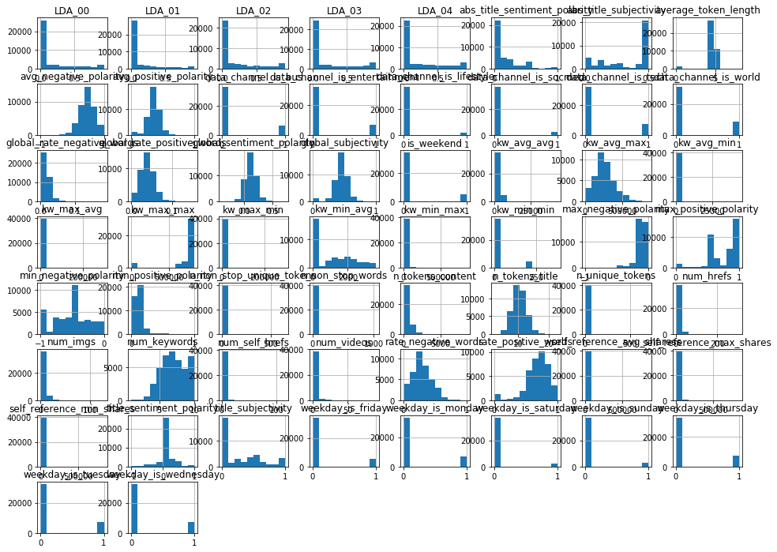

```python
# Histograms for each attribute
x_original.hist()
pyplot.show()
```

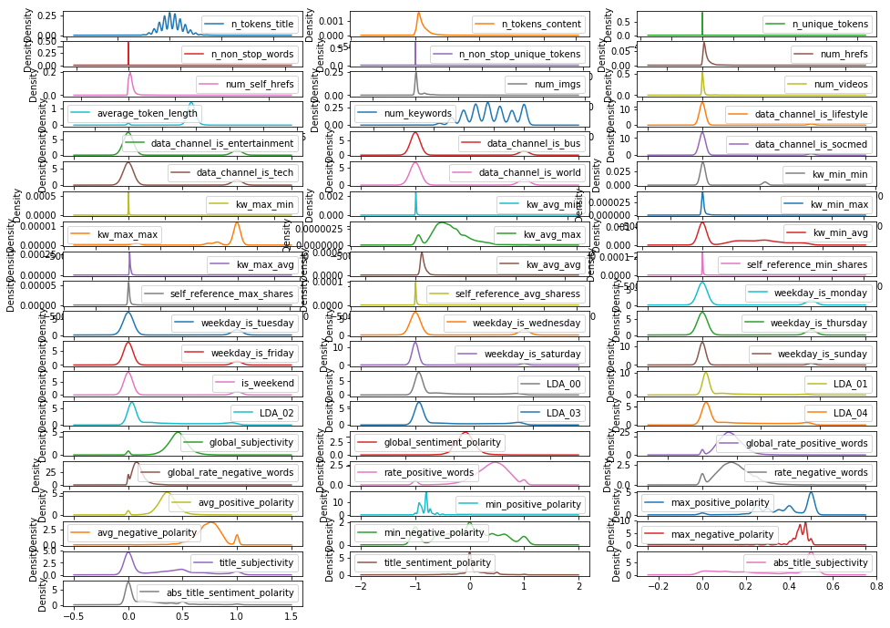

```python
# Density plot for each attribute
x_original.plot(kind='density', subplots=True, layout=(dispRow,dispCol), sharex=False, sharey=False)
pyplot.show()
```

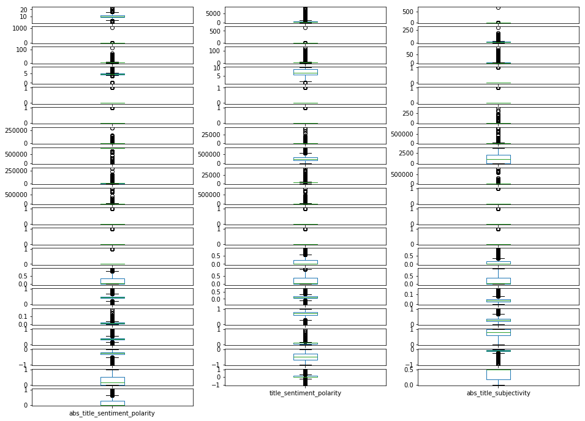

```python
# Box and Whisker plot for each attribute
x_original.plot(kind='box', subplots=True, layout=(dispRow,dispCol), sharex=False, sharey=False)
pyplot.show()
```

#### 2.b.ii) Multivariate plots to better understand the relationships between attributes

```python
# Scatterplot matrix
# scatter_matrix(x_original)
# pyplot.show()
```

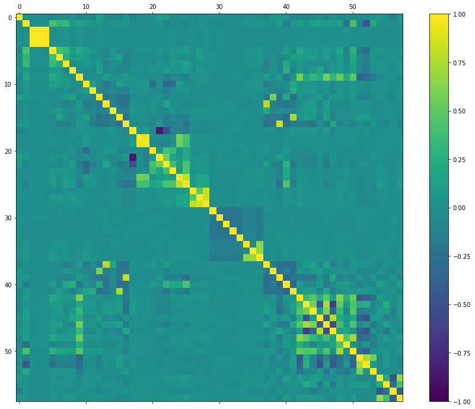

```python
# Correlation matrix
fig = pyplot.figure()
ax = fig.add_subplot(111)
cax = ax.matshow(x_original.corr(), vmin=-1, vmax=1)
fig.colorbar(cax)
pyplot.show()
```

```python
email_notify("Data Summary and Visualization Completed! "+datetime.now().strftime('%a %B %d, %Y %I:%M:%S %p'))
```

## Section 3 - Prepare Data

Some dataset may require additional preparation activities that will best exposes the structure of the problem and the relationships between the input attributes and the output variable. Some data-prep tasks might include:

- Cleaning data by removing duplicates, marking missing values and even imputing missing values.
- Feature selection where redundant features may be removed.
- Data transforms where attributes are scaled or redistributed in order to best expose the structure of the problem later to learning algorithms.

### 3.a) Data Cleaning

```python
# Not applicable for this iteration of the project.
```

### 3.b) Feature Selection

```python
# Feature Importance with Lasso
model = Lasso()
model.fit(x_train, y_train)
importanceScore = abs(model.coef_)
attributeList = xy_original.columns
attributeList = xy_original.columns.tolist()
if targetCol == totCol :
    del attributeList[-1]
else :
    del attributeList[0]
attributeImportance = pd.DataFrame({'attribute': attributeList, 'importance': importanceScore})
rankedAttributes = attributeImportance.sort_values('importance', ascending=False)
print(rankedAttributes)
```

```
                        attribute   importance
44     global_rate_positive_words  5560.044402
42            global_subjectivity  1960.220681
49          min_positive_polarity  1436.755471
53          max_negative_polarity  1393.310243
12  data_channel_is_entertainment   890.797146
56         abs_title_subjectivity   786.747698
39                         LDA_02   740.324597
34            weekday_is_saturday   704.933289
52          min_negative_polarity   692.263774
11      data_channel_is_lifestyle   621.250700
29              weekday_is_monday   586.571370
57   abs_title_sentiment_polarity   510.360826
4        n_non_stop_unique_tokens   396.532412
38                         LDA_01   389.260894
```

[output cut: 44 more lines]

```python
# Set the importance threshold and calculate the list of attributes that don't contribute to the importance threshold
importanceSum = sum(importanceScore)
maxThreshold = 0.99
i = 0
accumWeight = 0
exit_now = False
while ((i < totAttr) and (not exit_now)) :
    accumWeight = accumWeight + (rankedAttributes.iloc[i]['importance']/importanceSum)
    if (accumWeight >= maxThreshold) :
        exit_now = True
    else :
        i = i + 1
print('Number of attributes contributed to the importance threshold:'+str(i))
lowAttributes = rankedAttributes.iloc[(i):(totAttr),]['attribute'].tolist()
print('Number of attributes found to be of low importance:',len(lowAttributes))
print(lowAttributes)
```

[output not shown]

```python
# Removing the unselected attributes from the training and validation dataframes
#xy_train <- xy_train[, !(names(xy_train) %in% lowAttributes)]
#xy_test <- xy_test[, !(names(xy_test) %in% lowAttributes)]
xy_newdf = xy_original.drop(lowAttributes, axis=1)

totCol = len(xy_newdf.columns)
totAttr = totCol-1
targetCol = totCol
array = xy_newdf.values

if targetCol == totCol :
    x_newdf = array[:,0:totAttr]
    y_newdf = array[:,totAttr]
else :
    x_newdf = array[:,1:totCol]
    y_newdf = array[:,0]

validation_size = 0.30
x_train, x_test, y_train, y_test = train_test_split(x_newdf, y_newdf, test_size=validation_size, random_state=seedNum)
print("x_newdf.shape: {} y_newdf.shape: {}".format(x_newdf.shape, y_newdf.shape))
print("x_train.shape: {} y_train.shape: {}".format(x_train.shape, y_train.shape))
print("x_test.shape: {} y_test.shape: {}".format(x_test.shape, y_test.shape))
```

```
x_newdf.shape: (39644, 30) y_newdf.shape: (39644,)
x_train.shape: (27750, 30) y_train.shape: (27750,)
x_test.shape: (11894, 30) y_test.shape: (11894,)
```

### 3.c) Data Transforms

```python
# Not applicable for this iteration of the project.
```

### 3.d) Display the Final Dataset for Model-Building

```python
print('Data handling time:',(datetime.now() - startTimeScript))
```

```
Data handling time: 0:01:36.623327
```

```python
email_notify("Data Cleaning and Transformation Completed! "+datetime.now().strftime('%a %B %d, %Y %I:%M:%S %p'))
```

## 4. Model and Evaluate Algorithms

After the data-prep, we next work on finding a workable model by evaluating a subset of machine learning algorithms that are good at exploiting the structure of the training. The typical evaluation tasks include:

- Defining test options such as cross validation and the evaluation metric to use.
- Spot checking a suite of linear and nonlinear machine learning algorithms.
- Comparing the estimated accuracy of algorithms.

Linear Algorithms: Linear Regression, Ridge Regression, LASSO Regression, and Elastic Net Regression

Non-Linear Algorithms: Decision Trees (CART), k-Nearest Neighbors, and Support Vector Machine

The random number seed is reset before each run to ensure that the evaluation of each algorithm is performed using the same data splits. It ensures the results are directly comparable.

### 4.a) Set test options and evaluation metric

```python
# Run algorithms using 10-fold cross validation
num_folds = 10
scoring = 'neg_mean_squared_error'
```

```python
# Set up Algorithms Spot-Checking Array
models = []
models.append(('LR', LinearRegression()))
models.append(('RR', Ridge(random_state=seedNum)))
models.append(('LASSO', Lasso(random_state=seedNum)))
models.append(('EN', ElasticNet(random_state=seedNum)))
models.append(('CART', DecisionTreeRegressor(random_state=seedNum)))
models.append(('KNN', KNeighborsRegressor()))
models.append(('SVM', SVR()))
models.append(('RF', RandomForestRegressor(random_state=seedNum)))
models.append(('GBM', GradientBoostingRegressor(random_state=seedNum)))
results = []
names = []
metrics = []
```

```python
# Generate model in turn
for name, model in models:
	startTimeModule = datetime.now()
	kfold = KFold(n_splits=num_folds, random_state=seedNum)
	cv_results = cross_val_score(model, x_train, y_train, cv=kfold, scoring=scoring)
	results.append(cv_results)
	names.append(name)
	metrics.append(cv_results.mean())
	msg = "%s: %f (%f)" % (name, cv_results.mean(), cv_results.std())
	print(msg)
	print ('Model training time:',(datetime.now() - startTimeModule))
```

```
LR: -174487497.846365 (186729549.987316)
Model training time: 0:00:00.343647
RR: -155780972.809397 (133909992.971489)
Model training time: 0:00:00.144458
```

```
LASSO: -149581910.802585 (117102626.609564)
Model training time: 0:00:04.851577
EN: -129014359.009228 (66346526.401247)
Model training time: 0:00:00.590929
CART: -271582347.246018 (111358239.603726)
Model training time: 0:00:07.595095
KNN: -154846018.642096 (63736384.131479)
Model training time: 0:00:08.212526
SVM: -133429335.993487 (66366400.004052)
Model training time: 0:07:46.523756
RF: -155111835.356675 (70468053.920396)
Model training time: 0:00:47.803161
GBM: -130174642.841740 (65573197.178201)
Model training time: 0:00:38.884203
```

```python
print('Average metrics ('+scoring+') from all models:',np.mean(metrics))
print('Average error from all models:',math.sqrt(abs(np.mean(metrics))))
```

```
Average metrics (neg_mean_squared_error) from all models: -161556546.72751024
Average error from all models: 12710.48963366519
```

### 4.b) Spot-checking baseline algorithms

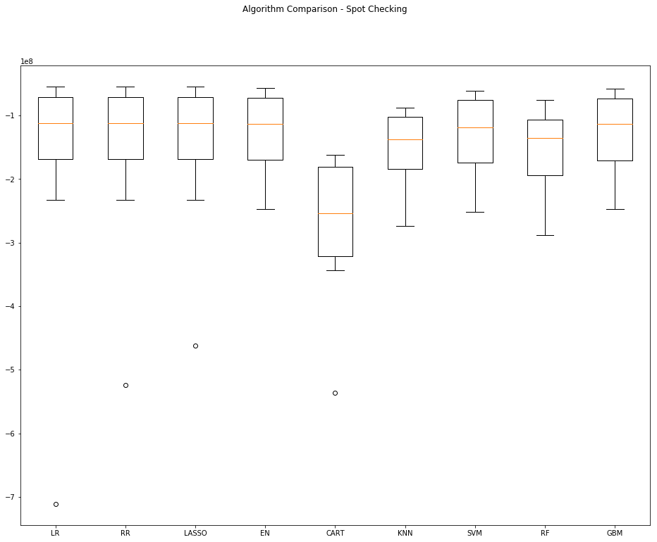

```python
fig = pyplot.figure()
fig.suptitle('Algorithm Comparison - Spot Checking')
ax = fig.add_subplot(111)
pyplot.boxplot(results)
ax.set_xticklabels(names)
pyplot.show()
```

```python
email_notify("Baseline Modeling Completed! "+datetime.now().strftime('%a %B %d, %Y %I:%M:%S %p'))
```

## Section 5 - Improve Accuracy

After we achieve a short list of machine learning algorithms with good level of accuracy, we can leverage ways to improve the accuracy of the models.

### 5.a) Algorithm Tuning

```python
# Set up the comparison array
results = []
names = []
```

```python
# Tuning algorithm #1 - ElasticNet
startTimeModule = datetime.now()
paramGrid1 = dict(alpha=np.array([1,2,3]))
model1 = ElasticNet(random_state=seedNum)
kfold = KFold(n_splits=num_folds, random_state=seedNum)
grid1 = GridSearchCV(estimator=model1, param_grid=paramGrid1, scoring=scoring, cv=kfold)
grid_result1 = grid1.fit(x_train, y_train)

print("Best: %f using %s" % (grid_result1.best_score_, grid_result1.best_params_))
results.append(grid_result1.cv_results_['mean_test_score'])
names.append('EN')
means = grid_result1.cv_results_['mean_test_score']
stds = grid_result1.cv_results_['std_test_score']
params = grid_result1.cv_results_['params']
for mean, stdev, param in zip(means, stds, params):
    print("%f (%f) with: %r" % (mean, stdev, param))
email_notify("Algorithm #1 Tuning Completed! "+datetime.now().strftime('%a %B %d, %Y %I:%M:%S %p'))
print ('Model training time:',(datetime.now() - startTimeModule))
```

```
Best: -129014359.009228 using {'alpha': 1}
-129014359.009228 (66346526.401247) with: {'alpha': 1}
-129240686.741656 (66325776.907726) with: {'alpha': 2}
-129334149.561990 (66298769.702133) with: {'alpha': 3}
Model training time: 0:00:02.706922
```

```python
# Tuning algorithm #2 - Stochastic Gradient Boosting
startTimeModule = datetime.now()
paramGrid2 = dict(n_estimators=np.array([100,200,300,400]))
model2 = GradientBoostingRegressor(random_state=seedNum)
kfold = KFold(n_splits=num_folds, random_state=seedNum)
grid2 = GridSearchCV(estimator=model2, param_grid=paramGrid2, scoring=scoring, cv=kfold)
grid_result2 = grid2.fit(x_train, y_train)

print("Best: %f using %s" % (grid_result2.best_score_, grid_result2.best_params_))
results.append(grid_result2.cv_results_['mean_test_score'])
names.append('GBM')
means = grid_result2.cv_results_['mean_test_score']
stds = grid_result2.cv_results_['std_test_score']
params = grid_result2.cv_results_['params']
for mean, stdev, param in zip(means, stds, params):
    print("%f (%f) with: %r" % (mean, stdev, param))
email_notify("Algorithm #2 Tuning Completed! "+datetime.now().strftime('%a %B %d, %Y %I:%M:%S %p'))
print ('Model training time:',(datetime.now() - startTimeModule))
```

```
Best: -130174642.841741 using {'n_estimators': 100}
-130174642.841741 (65573197.178201) with: {'n_estimators': 100}
-133029201.732996 (66148165.173677) with: {'n_estimators': 200}
-135750222.787882 (67669201.345814) with: {'n_estimators': 300}
-138024507.339213 (68327924.965248) with: {'n_estimators': 400}
Model training time: 0:06:17.717388
```

### 5.b) Compare Algorithms After Tuning

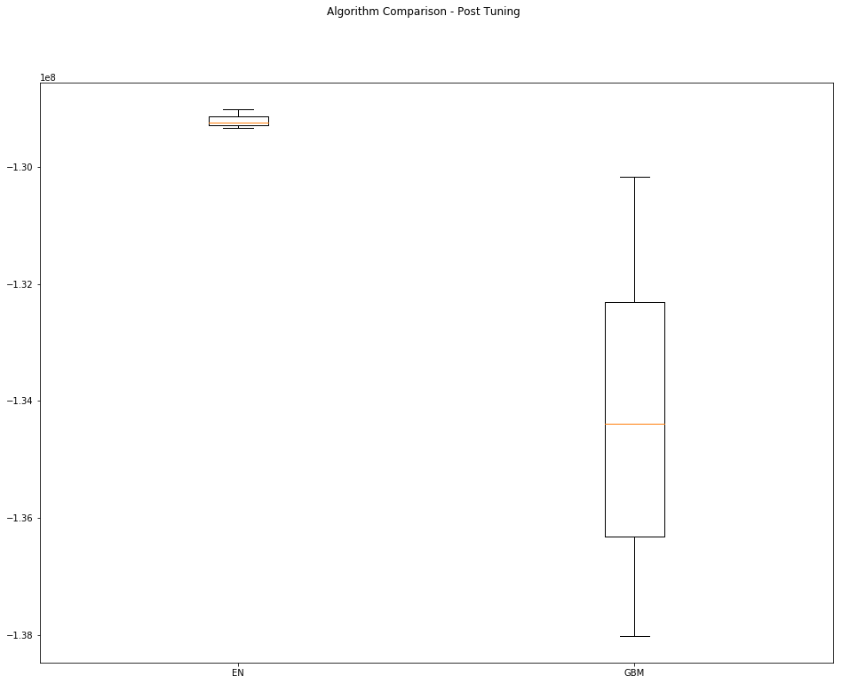

```python
fig = pyplot.figure()
fig.suptitle('Algorithm Comparison - Post Tuning')
ax = fig.add_subplot(111)
pyplot.boxplot(results)
ax.set_xticklabels(names)
pyplot.show()
```

## Section 6 - Finalize Model

Once we have narrow down to a model that we believe can make accurate predictions on unseen data, we are ready to finalize it. Finalizing a model may involve sub-tasks such as:

- Using an optimal model tuned to make predictions on unseen data.
- Creating a standalone model using the tuned parameters
- Saving an optimal model to file for later use.

### 6.a) Predictions on validation dataset

```python
model = ElasticNet(alpha=1, random_state=seedNum)
model.fit(x_train, y_train)
predictions = model.predict(x_test)
print(mean_squared_error(y_test, predictions))
```

```
147525845.6885829
```

### 6.b) Create standalone model on entire training dataset

```python
startTimeModule = datetime.now()
finalModel = ElasticNet(alpha=1, random_state=seedNum)
finalModel.fit(x_original, y_original)
print('Model training time:',(datetime.now() - startTimeModule))
```

```
Model training time: 0:00:00.372402
```

### 6.c) Save model for later use

```python
# modelName = 'finalModel_BinaryClass.sav'
# dump(finalModel, modelName)

email_notify("Prediction Testing and Model Finalization Completed! "+datetime.now().strftime('%a %B %d, %Y %I:%M:%S %p'))
print('Total time for the script:',(datetime.now() - startTimeScript))
```

```
Total time for the script: 0:17:37.705318
```